# Practical Machine Learnig course project

Naveen kumar

8/21/2020

Loading the required libraries

```r
library(caret)
library(randomForest)
```

```r
library(rpart)
library(rpart.plot)
library(rattle)
#install.packages('caret', dependencies = TRUE)
set.seed(125)
```

Getting the data

```r
trainurl<-"https://d396qusza40orc.cloudfront.net/predmachlearn/pml-training.csv"
testurl<-"https://d396qusza40orc.cloudfront.net/predmachlearn/pml-testing.csv"
```

Loading the data

```r
training <- read.csv(url(trainurl))
testing <- read.csv(url(testurl))
```

```r
dim(training)
```

```
## [1] 19622   160
```

```r
dim(testing)
```

```
## [1]  20 160
```

we will clean the data and get rid of observations with missing values as well as some unnecessary variables.

```r
sum(complete.cases(training))
```

```
## [1] 406
```

```r
training$classe <- as.factor(training$classe)
```

Now,we remove columns the that contain NA missing values

```r
training <- training[, colSums(is.na(training)) == 0]
testing <- testing[, colSums(is.na(testing)) == 0]
```

we also remove some columns like index,date etc,. for easy computation

```r
classe <- training$classe
trainRemove <- grepl("^X|timestamp|window", names(training))
training <- training[, !trainRemove]
trainupdated <- training[, sapply(training, is.numeric)]
trainupdated$classe <- classe
testRemove <- grepl("^X|timestamp|window", names(testing))
testing <- testing[, !testRemove]
testupdated <- testing[, sapply(testing, is.numeric)]
```

```r
dim(trainupdated)
```

```
## [1] 19622    53
```

```r
dim(testupdated)
```

```
## [1] 20 53
```

we can split the cleaned training set into training data set (70%) and a validation data set (30%).

```r
Train <- createDataPartition(trainupdated$classe, p=0.70, list=F)
trainData <- trainupdated[Train, ]
testData <- trainupdated[-Train, ]
```

Training by RANDOM FOREST:

We fit a predictive model for activity recognition using **Random Forest** algorithm because it automatically selects important variables and is robust to correlated covariates & outliers in general. We will use **5-fold cross validation** when applying the algorithm.

```r
controlRf <- trainControl(method="cv", 5)
#install.packages('e1071', dependencies=TRUE)
```

```r
modelRf <- train(classe ~ ., data=trainData, method="rf", trControl=controlRf, ntree=250)
modelRf
```

```
## Random Forest
##
## 13737 samples
##    52 predictor
##     5 classes: 'A', 'B', 'C', 'D', 'E'
##
## No pre-processing
## Resampling: Cross-Validated (5 fold)
## Summary of sample sizes: 10990, 10989, 10991, 10989, 10989
## Resampling results across tuning parameters:
##
##   mtry  Accuracy   Kappa
##    2    0.9895904  0.9868302
##   27    0.9904639  0.9879371
##   52    0.9836210  0.9792787
##
## Accuracy was used to select the optimal model using the largest value.
## The final value used for the model was mtry = 27.
```

Prediction:

```r
predictRf <- predict(modelRf, testData)
confusionMatrix(testData$classe, predictRf) #using confusion matrix to see the predictions
```

```
## Confusion Matrix and Statistics
##
##           Reference
## Prediction    A    B    C    D    E
##          A 1672    0    2    0    0
##          B    9 1128    2    0    0
##          C    0   12 1011    3    0
##          D    0    1   15  947    1
##          E    0    0    1    0 1081
##
## Overall Statistics
##
##                Accuracy : 0.9922
##                  95% CI : (0.9896, 0.9943)
##     No Information Rate : 0.2856
##     P-Value [Acc > NIR] : < 2.2e-16
##
##                   Kappa : 0.9901
##
##  Mcnemar's Test P-Value : NA
##
## Statistics by Class:
##
##                      Class: A Class: B Class: C Class: D Class: E
## Sensitivity            0.9946   0.9886   0.9806   0.9968   0.9991
## Specificity            0.9995   0.9977   0.9969   0.9966   0.9998
## Pos Pred Value         0.9988   0.9903   0.9854   0.9824   0.9991
## Neg Pred Value         0.9979   0.9973   0.9959   0.9994   0.9998
## Prevalence             0.2856   0.1939   0.1752   0.1614   0.1839
## Detection Rate         0.2841   0.1917   0.1718   0.1609   0.1837
## Detection Prevalence   0.2845   0.1935   0.1743   0.1638   0.1839
## Balanced Accuracy      0.9971   0.9931   0.9888   0.9967   0.9994
```

Accuracy:

```r
accuracy <- postResample(predictRf, testData$classe)
accuracy
```

```
##  Accuracy     Kappa
## 0.9921835 0.9901112
```

DECISION TREE:

we will train the model using decision tree

```r
modFitDC <- rpart(classe ~ ., data=trainData, method="class")
```

To view the decision tree with fancy to knnow how the data is segregated

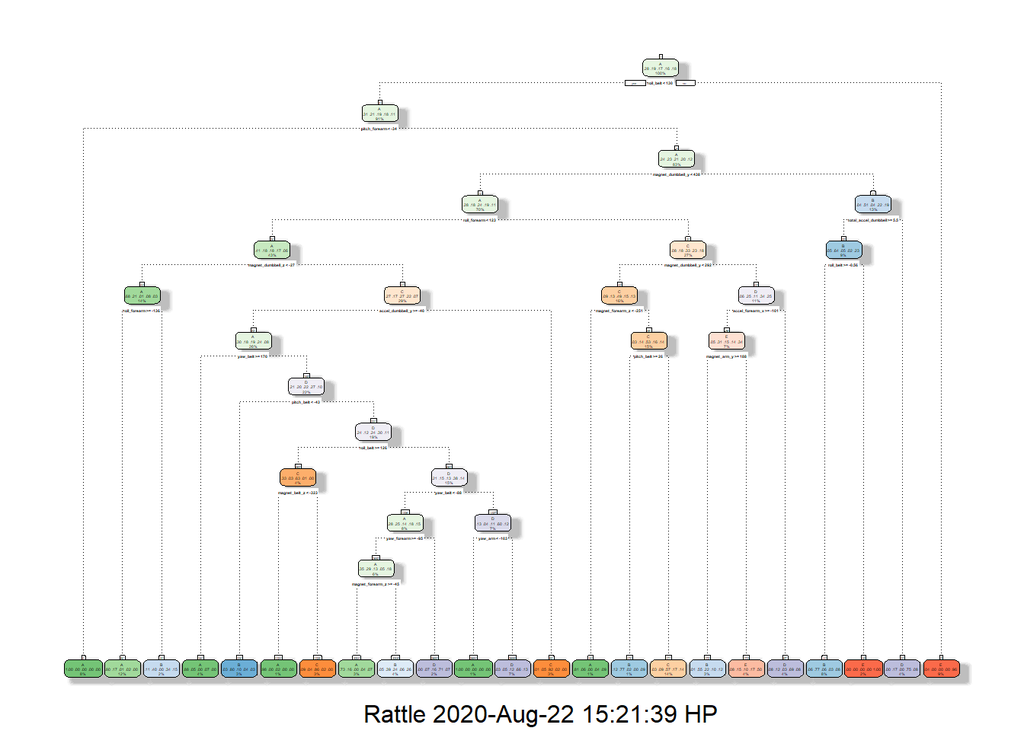

```r
fancyRpartPlot(modFitDC)
```

Prediction:

```r
predictionDC <- predict(modFitDC,testData, type = "class")
```

Using confusion Matrix to test results

```r
confusionMatrix(predictionDC, testData$classe)
```

```
## Confusion Matrix and Statistics
##
##           Reference
## Prediction    A    B    C    D    E
##          A 1498  176   21   33   21
##          B   61  772  143   97  109
##          C   43   82  762  151  128
##          D   28   77   71  635   98
##          E   44   32   29   48  726
##
## Overall Statistics
##
##                Accuracy : 0.7465
##                  95% CI : (0.7352, 0.7575)
##     No Information Rate : 0.2845
##     P-Value [Acc > NIR] : < 2.2e-16
##
##                   Kappa : 0.6788
##
##  Mcnemar's Test P-Value : < 2.2e-16
##
## Statistics by Class:
##
##                      Class: A Class: B Class: C Class: D Class: E
## Sensitivity            0.8949   0.6778   0.7427   0.6587   0.6710
## Specificity            0.9404   0.9136   0.9169   0.9443   0.9681
## Pos Pred Value         0.8565   0.6531   0.6535   0.6986   0.8259
## Neg Pred Value         0.9574   0.9220   0.9441   0.9339   0.9289
## Prevalence             0.2845   0.1935   0.1743   0.1638   0.1839
## Detection Rate         0.2545   0.1312   0.1295   0.1079   0.1234
## Detection Prevalence   0.2972   0.2008   0.1981   0.1545   0.1494
## Balanced Accuracy      0.9176   0.7957   0.8298   0.8015   0.8196
```

Twsting the model:

```r
testingPred <- predict(modelRf, testupdated)
testingPred
```

```
##  [1] B A B A A E D B A A B C B A E E A B B B
## Levels: A B C D E
```